# Factor Analysis for Detector Dog C-BARQ for Combined Phase 1 and Phase 2 Data

Version 3.0 with 15 factors

Liz Hare, PhD

lizhare@gmail.com

2023-09-01

# 1 15-Factor Model with Item MISC69 removed

Item MISC69 is “Chases/follows shadows, light spots, etc.” We decided to remove it because it sorted with fear of underfootings

## 1.1 Imputation

Categorical missing values using multiple Correspondence Analysis (also called Missing Fuzzy Average method) Josseet al (201 0)

## 1.2 Tests of Suitability for Factor Analysis

### 1.2.1 Pre-imputation

#### 1.2.1.1 Bartlett’s Test

This is a test that the matrix is an identity matrix. This would mean that the correlations were not significantly different from 0. If it’s not significant, the matrix is not suitable because the variables show too little covariance.

The chi-squared for the Bartlett test is 3.605142^{4} with 1225 DF, p = 0e+00.

#### 1.2.1.2 Kaiser-Meyer-Olkin Criterion (KMO)

From EFAtools::KMO documentation:

> The KMO represents the degree to which each observed variable is predicted by the other variables in the dataset and with this indicates the suitability for factor analysis

The numeric version of the dataset is used because stats::cor is used to find the correlation and it requires numeric input. Used option for Spearman correlation because of ordered variables.

```
## ℹ 'x' was not a correlation matrix. Correlations are found from entered raw data.
```

[1] 0.846506

### 1.2.2 Post-imputation

#### 1.2.2.1 Bartlett’s Test

This is a test that the matrix is an identity matrix. This would mean that the correlations were not significantly different from 0. If it’s not significant, the matrix is not suitable because the variables show too little covariance.

The chi-squared for the Bartlett test is 3.4828253^{4} with 1225 DF, p = 0e+00.

#### 1.2.2.2 Kaiser-Meyer-Olkin Criterion (KMO)

From EFAtools::KMO documentation:

> The KMO represents the degree to which each observed variable is predicted by the other variables in the dataset and with this indicates the suitability for factor analysis

```
## ℹ 'x' was not a correlation matrix. Correlations are found from entered raw data.
```

## 1.3 Between-Item Correlations

### 1.3.1 Pre-imputation

For factor analysis, it is recommended that some of the item correlationsshould be between 0.3 and 0.9. Polychoric correlations were computed using the `polychoric` function in the `psych` package in R with options `smooth = TRUE` to adjust for non-positive-definite matrices and `correct = 0.01` to avoid computation problems with covariance of zero.

The minimum correlation in this data set is -0.477. The maximum correlation in this data set is 0.856.

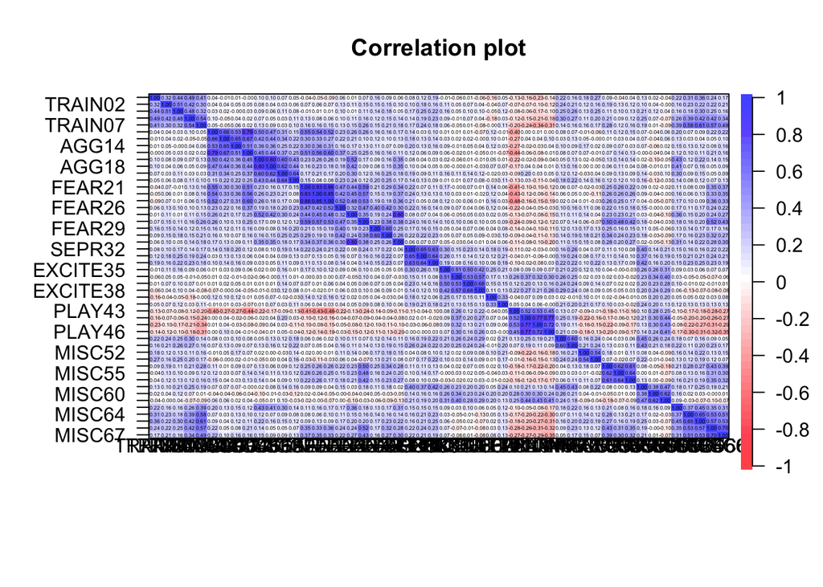

### 1.3.2 Post-imputation

The post imputation polyserial correlation was also computed using the `polychoric` function, with no setting `smooth = TRUE` and `correct = 0.01.`

The minimum correlation was -0.466. The maximum correlation was 0.851.

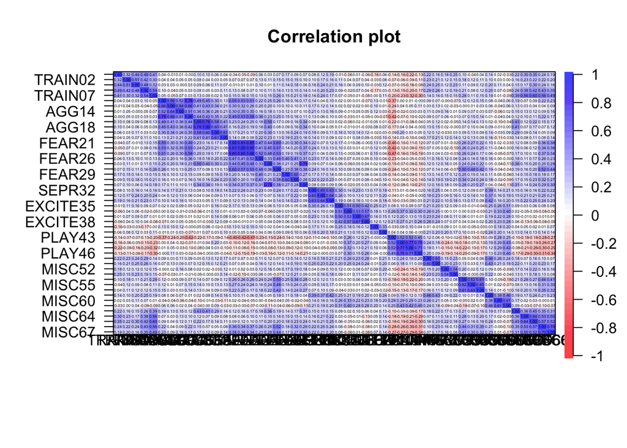

## 1.4 Factor Analysis for 15 Factor Model

Although the chi-square test of goodness of fit is sensitive to departures from normality like the C-BARQ items, Hopper et al (2008) recommend always reporting it.

- chi-square: 4407.2111128
- degrees of freedom: 580
- P-value for chi-square = 0e+00

Tucker-Lewis Index of Factoring Reliability/Non-Norm Fit Index: 0.7571502. Should be > 0.9; need reference)

## 1.5 Communalities

|  | fanal15.communality |
| --- | --- |
| TRAIN01 | 0.44 |
| TRAIN02 | 0.40 |
| TRAIN03 | 0.61 |
| TRAIN04 | 0.60 |
| TRAIN07 | 0.62 |
| AGG09 | 0.77 |
| AGG10 | 0.69 |
| AGG14 | 0.50 |
| AGG15 | 0.80 |
| AGG16 | 0.76 |
| AGG18 | 0.75 |
| AGG19 | 0.79 |
| AGG20 | 0.52 |
| FEAR21 | 0.84 |
| FEAR23 | 0.80 |
| FEAR24 | 0.90 |
| FEAR26 | 0.44 |
| FEAR27 | 0.84 |
| FEAR28 | 0.63 |
| FEAR29 | 0.61 |
| FEAR30 | 0.63 |
| FEAR31 | 0.71 |
| SEPR32 | 0.69 |
| SEPR33 | 0.66 |
| SEPR34 | 0.66 |
| EXCITE35 | 0.48 |
| EXCITE36 | 0.57 |
| EXCITE37 | 0.65 |
| EXCITE38 | 0.66 |
| ATT39 | 0.53 |
| ATT41 | 0.32 |
| PLAY43 | 0.55 |
| PLAY44 | 0.84 |
| PLAY45 | 0.77 |
| PLAY46 | 0.72 |
| IMP47 | 0.59 |
| IMP48 | 0.58 |
| MISC52 | 0.57 |
| MISC53 | 0.60 |
| MISC54 | 0.64 |
| MISC55 | 0.73 |
| MISC56 | 0.62 |
| MISC59 | 0.59 |
| MISC60 | 0.61 |
| MISC61 | 0.70 |
| MISC62 | 0.45 |
| MISC64 | 0.60 |
| MISC65 | 0.65 |
| MISC66 | 0.69 |
| MISC67 | 0.59 |

### 1.5.1 How many communalities < 0.40?

THere are 1 items with communality < 0.40.

|  | fanal15.communality | item |
| --- | --- | --- |
| ATT41 | 0.32 | ATT41 |

## 1.6 Loadings

|  | PA1 | PA3 | PA12 | PA2 | PA5 | PA6 | PA7 | PA4 | PA9 | PA8 | PA11 | PA15 | PA13 | PA10 | PA14 |
| --- | --- | --- | --- | --- | --- | --- | --- | --- | --- | --- | --- | --- | --- | --- | --- |
| TRAIN01 | -0.09 | 0.21 | 0.04 | -0.06 | -0.09 | -0.06 | 0.00 | 0.01 | 0.01 | 0.46 | 0.05 | 0.03 | 0.04 | 0.11 | -0.14 |
| TRAIN02 | 0.03 | 0.02 | 0.02 | 0.04 | 0.07 | 0.02 | 0.02 | -0.08 | 0.02 | 0.60 | 0.05 | 0.04 | -0.06 | 0.01 | 0.05 |
| TRAIN03 | 0.01 | -0.05 | -0.05 | -0.02 | 0.06 | 0.01 | 0.07 | 0.04 | -0.07 | 0.75 | 0.04 | 0.02 | 0.04 | 0.05 | 0.04 |
| TRAIN04 | 0.06 | 0.33 | -0.02 | -0.03 | -0.04 | 0.04 | 0.03 | -0.05 | 0.02 | 0.48 | -0.04 | 0.16 | -0.05 | -0.01 | -0.20 |
| TRAIN07 | 0.06 | 0.66 | -0.09 | -0.05 | -0.06 | 0.00 | 0.02 | 0.01 | 0.00 | 0.22 | 0.01 | 0.02 | -0.05 | -0.02 | 0.00 |
| AGG09 | 0.20 | 0.03 | 0.75 | 0.00 | 0.05 | -0.05 | -0.06 | -0.01 | -0.02 | 0.04 | 0.04 | 0.06 | 0.07 | -0.09 | 0.03 |
| AGG10 | -0.06 | -0.04 | 0.82 | 0.07 | -0.03 | 0.01 | 0.12 | 0.01 | 0.02 | -0.02 | 0.04 | 0.02 | -0.07 | -0.01 | 0.05 |
| AGG14 | 0.01 | 0.09 | 0.66 | 0.05 | -0.01 | 0.06 | 0.12 | 0.02 | 0.00 | -0.06 | -0.04 | 0.02 | -0.14 | 0.09 | 0.07 |
| AGG15 | 0.29 | 0.00 | 0.72 | -0.05 | 0.03 | 0.01 | -0.05 | 0.11 | -0.09 | -0.01 | 0.06 | -0.04 | 0.09 | 0.07 | -0.13 |
| AGG16 | -0.12 | 0.05 | 0.30 | -0.06 | 0.06 | -0.03 | -0.06 | 0.50 | 0.33 | 0.10 | -0.06 | 0.01 | 0.01 | -0.13 | 0.10 |
| AGG18 | -0.15 | -0.01 | 0.29 | -0.04 | 0.00 | -0.10 | -0.05 | 0.52 | 0.29 | 0.07 | -0.03 | 0.10 | 0.08 | -0.09 | 0.15 |
| AGG19 | 0.06 | 0.03 | 0.00 | 0.08 | 0.02 | 0.08 | 0.03 | 0.87 | -0.01 | 0.01 | 0.05 | -0.08 | 0.02 | 0.00 | -0.05 |
| AGG20 | 0.04 | -0.02 | -0.07 | -0.03 | 0.02 | 0.00 | 0.03 | 0.68 | -0.08 | -0.07 | 0.09 | 0.18 | -0.15 | 0.09 | 0.00 |
| FEAR21 | 0.83 | 0.01 | 0.08 | 0.00 | 0.03 | -0.01 | -0.01 | 0.01 | 0.05 | 0.00 | 0.07 | 0.03 | 0.01 | -0.02 | 0.03 |
| FEAR23 | 0.76 | 0.00 | 0.13 | -0.02 | 0.06 | -0.03 | 0.06 | -0.01 | 0.13 | 0.00 | -0.05 | 0.02 | 0.01 | -0.05 | 0.03 |
| FEAR24 | 0.87 | 0.01 | 0.08 | -0.05 | -0.02 | 0.03 | -0.02 | 0.02 | 0.12 | 0.00 | 0.00 | -0.04 | 0.00 | 0.02 | 0.04 |
| FEAR26 | 0.38 | 0.00 | 0.00 | 0.07 | -0.02 | -0.03 | 0.04 | 0.09 | 0.06 | 0.03 | 0.40 | 0.00 | 0.01 | 0.05 | 0.01 |
| FEAR27 | 0.18 | 0.00 | -0.03 | 0.02 | 0.02 | 0.01 | 0.03 | 0.05 | 0.84 | -0.02 | 0.01 | -0.01 | -0.02 | 0.05 | -0.04 |
| FEAR28 | 0.45 | 0.12 | -0.09 | 0.04 | 0.36 | 0.05 | 0.03 | -0.01 | 0.05 | 0.01 | 0.16 | 0.07 | -0.07 | -0.12 | 0.02 |
| FEAR29 | -0.07 | -0.02 | 0.08 | -0.04 | -0.05 | 0.01 | -0.01 | -0.03 | 0.04 | 0.05 | 0.80 | -0.02 | 0.04 | -0.01 | 0.02 |
| FEAR30 | 0.00 | 0.03 | -0.02 | 0.01 | 0.08 | -0.01 | 0.07 | 0.10 | 0.02 | -0.02 | 0.70 | 0.03 | -0.04 | 0.04 | -0.04 |
| FEAR31 | 0.08 | 0.02 | -0.07 | -0.02 | 0.05 | 0.02 | 0.03 | -0.07 | 0.78 | -0.02 | 0.12 | 0.05 | -0.04 | 0.02 | 0.00 |
| SEPR32 | 0.08 | -0.01 | 0.01 | -0.06 | -0.04 | 0.07 | 0.77 | 0.06 | -0.01 | -0.03 | 0.04 | 0.04 | -0.01 | -0.09 | 0.07 |
| SEPR33 | -0.06 | 0.03 | 0.00 | 0.02 | 0.03 | -0.01 | 0.79 | -0.03 | 0.04 | 0.07 | 0.03 | -0.01 | 0.00 | 0.01 | 0.04 |
| SEPR34 | -0.05 | 0.02 | 0.07 | -0.01 | 0.05 | -0.03 | 0.78 | -0.03 | 0.03 | 0.03 | 0.00 | -0.01 | 0.06 | 0.07 | -0.07 |
| EXCITE35 | 0.14 | 0.02 | -0.05 | -0.07 | -0.07 | 0.55 | 0.13 | 0.04 | -0.01 | 0.08 | -0.05 | -0.04 | 0.11 | 0.04 | 0.16 |
| EXCITE36 | 0.01 | 0.01 | 0.00 | 0.13 | 0.02 | 0.64 | -0.06 | -0.01 | -0.07 | 0.00 | 0.06 | 0.03 | 0.13 | -0.05 | 0.06 |
| EXCITE37 | -0.02 | 0.03 | 0.04 | -0.05 | -0.02 | 0.82 | 0.02 | 0.03 | 0.03 | -0.01 | -0.03 | 0.00 | 0.00 | 0.02 | -0.02 |
| EXCITE38 | -0.05 | -0.08 | 0.01 | 0.03 | 0.05 | 0.79 | -0.02 | 0.01 | 0.04 | -0.01 | 0.02 | 0.07 | -0.03 | 0.00 | -0.04 |
| ATT39 | 0.10 | 0.02 | 0.01 | 0.03 | -0.04 | 0.06 | 0.03 | -0.04 | -0.07 | -0.02 | 0.00 | -0.07 | 0.07 | 0.05 | 0.68 |
| ATT41 | 0.03 | 0.05 | -0.13 | 0.03 | 0.00 | -0.02 | 0.08 | 0.05 | -0.06 | 0.03 | 0.00 | 0.18 | 0.04 | 0.15 | 0.45 |
| PLAY43 | -0.28 | 0.01 | -0.23 | 0.51 | 0.02 | 0.08 | -0.04 | -0.07 | 0.10 | -0.05 | -0.01 | 0.01 | 0.07 | 0.03 | -0.02 |
| PLAY44 | 0.01 | 0.04 | -0.03 | 0.88 | -0.02 | 0.03 | -0.02 | 0.11 | -0.01 | 0.01 | 0.03 | 0.04 | 0.02 | -0.08 | 0.00 |
| PLAY45 | 0.02 | -0.01 | 0.04 | 0.84 | -0.03 | -0.03 | -0.05 | -0.06 | 0.06 | -0.05 | -0.02 | 0.01 | 0.07 | 0.01 | 0.07 |
| PLAY46 | 0.00 | -0.10 | 0.12 | 0.80 | 0.02 | 0.02 | 0.05 | 0.00 | -0.07 | 0.03 | -0.05 | 0.00 | -0.01 | 0.01 | -0.05 |
| IMP47 | 0.02 | -0.05 | 0.04 | 0.12 | -0.03 | 0.08 | -0.02 | -0.01 | 0.04 | 0.14 | 0.00 | 0.63 | 0.07 | 0.09 | -0.02 |
| IMP48 | -0.07 | 0.00 | 0.06 | 0.02 | 0.00 | 0.10 | 0.04 | -0.01 | 0.03 | 0.03 | 0.03 | 0.69 | 0.00 | 0.03 | 0.01 |
| MISC52 | -0.03 | 0.06 | 0.10 | -0.06 | 0.05 | 0.03 | -0.06 | -0.06 | 0.10 | -0.02 | 0.04 | 0.02 | -0.02 | 0.69 | 0.11 |
| MISC53 | 0.01 | -0.02 | -0.04 | -0.01 | 0.00 | -0.02 | 0.03 | 0.08 | 0.00 | 0.08 | 0.00 | 0.05 | 0.00 | 0.74 | -0.03 |
| MISC54 | -0.01 | 0.15 | -0.01 | -0.03 | 0.68 | 0.05 | -0.03 | -0.02 | 0.00 | 0.01 | 0.10 | 0.03 | -0.10 | 0.03 | 0.07 |
| MISC55 | 0.01 | -0.05 | -0.01 | 0.04 | 0.87 | -0.01 | 0.06 | 0.05 | 0.00 | 0.04 | -0.03 | -0.08 | 0.01 | -0.02 | -0.01 |
| MISC56 | -0.04 | 0.00 | 0.04 | -0.08 | 0.77 | -0.02 | -0.03 | -0.02 | 0.03 | -0.02 | -0.01 | 0.05 | 0.08 | 0.05 | -0.06 |
| MISC59 | 0.08 | 0.10 | -0.09 | 0.03 | 0.00 | -0.04 | 0.27 | 0.10 | -0.08 | -0.07 | 0.01 | 0.41 | 0.35 | 0.06 | -0.07 |
| MISC60 | -0.04 | -0.01 | -0.05 | 0.03 | 0.05 | 0.06 | -0.01 | -0.11 | 0.02 | 0.04 | 0.05 | 0.05 | 0.72 | 0.01 | 0.07 |
| MISC61 | 0.04 | -0.02 | 0.01 | 0.15 | -0.04 | 0.10 | 0.11 | 0.04 | -0.09 | -0.03 | -0.04 | 0.01 | 0.67 | -0.03 | 0.02 |
| MISC62 | -0.11 | 0.39 | 0.06 | -0.07 | -0.01 | 0.03 | -0.04 | 0.17 | 0.31 | 0.03 | 0.00 | 0.03 | 0.22 | 0.01 | 0.03 |
| MISC64 | -0.09 | 0.79 | 0.06 | 0.02 | 0.01 | -0.02 | 0.05 | 0.00 | -0.03 | -0.01 | 0.01 | -0.09 | 0.01 | 0.04 | 0.02 |
| MISC65 | -0.09 | 0.75 | 0.03 | -0.02 | -0.02 | 0.00 | 0.02 | 0.06 | 0.06 | 0.04 | 0.03 | 0.00 | 0.02 | 0.07 | -0.01 |
| MISC66 | 0.20 | 0.62 | -0.01 | -0.05 | 0.18 | -0.04 | 0.04 | -0.07 | -0.02 | 0.00 | 0.04 | 0.11 | -0.04 | -0.03 | 0.01 |
| MISC67 | 0.17 | 0.57 | 0.00 | -0.12 | 0.16 | -0.02 | 0.03 | -0.02 | 0.01 | -0.07 | 0.02 | 0.11 | -0.01 | -0.04 | 0.07 |

### 1.6.1 Largest Loading per Item

Communality, Largest Loading and factor sorted by Factor

|  | Factor | Item | Communality | Maximum Loading | Description |
| --- | --- | --- | --- | --- | --- |
| 15 | 1 | FEAR21 | 0.84 | 0.83 | When an unfamiliar person approaches the dog when s/he is away from his/her normal home environment or kennel |
| 16 | 1 | FEAR23 | 0.80 | 0.76 | When an unfamiliar person visits your home or approaches the dog when in his/her home kennel |
| 17 | 1 | FEAR24 | 0.90 | 0.87 | When an unfamiliar person tries to touch or pet the dog |
| 20 | 1 | FEAR28 | 0.63 | 0.45 | When first exposed to unfamiliar situations (e.g., novel environments, first visit to the veterinarian, etc.) |
| 39 | 2 | PLAY43 | 0.55 | 0.51 | Eagerly engages in play with new/unfamiliar people |
| 40 | 2 | PLAY44 | 0.84 | 0.88 | Highly toy focused; attention riveted on tug toy/balls when these are held by handler or other person |
| 41 | 2 | PLAY45 | 0.77 | 0.84 | Eagerly initiates play sessions; brings objects/toys to you/the handler and retrieves them when thrown |
| 42 | 2 | PLAY46 | 0.72 | 0.80 | Hunts persistently for thrown or hidden toys/objects, not easily distracted from this task |
| 34 | 3 | MISC62 | 0.45 | 0.39 | Becomes highly excited and/or distracted when encountering unfamiliar dogs |
| 35 | 3 | MISC64 | 0.60 | 0.79 | When working, is easily distracted or preoccupied by odors/engages in persistent sniffing of ground or objects |
| 36 | 3 | MISC65 | 0.65 | 0.75 | Has difficulty shifting attention away from interesting or distracting stimuli (e.g., other dogs, odor, people, small animals, etc.) |
| 37 | 3 | MISC66 | 0.69 | 0.62 | Is distracted or nervous in new, unfamiliar environments, has difficulty maintaining focus on work |
| 38 | 3 | MISC67 | 0.59 | 0.57 | Is slow to recover after being distracted, startled, or frightened/takes a long time to resume work |
| 50 | 3 | TRAIN07 | 0.62 | 0.66 | Unfocused; is easily distracted by interesting sights, sounds or smells |
| 5 | 4 | AGG16 | 0.76 | 0.50 | When approached directly by an unfamiliar dog while being walked/exercised on a leash |
| 6 | 4 | AGG18 | 0.75 | 0.52 | When barked, growled, or lunged at by another dog |
| 7 | 4 | AGG19 | 0.79 | 0.87 | Towards other familiar dogs |
| 8 | 4 | AGG20 | 0.52 | 0.68 | When approached while playing with/chewing a favorite toy, bone, object, etc. by another familiar dog |
| 28 | 5 | MISC54 | 0.64 | 0.68 | Reluctant to/nervous about crossing grates or other unfamiliar surfaces |
| 29 | 5 | MISC55 | 0.73 | 0.87 | Reluctant to/nervous about crossing shiny or slippery floors |
| 30 | 5 | MISC56 | 0.62 | 0.77 | Nervous or frightened when ascending or descending some types of stairs |
| 11 | 6 | EXCITE35 | 0.48 | 0.55 | Excitable when you first arrive home, or at the dog’s kennel, after a brief absence |
| 12 | 6 | EXCITE36 | 0.57 | 0.64 | Excitable when playing with you or other familiar persons |
| 13 | 6 | EXCITE37 | 0.65 | 0.82 | Excitable just before being taken out for a walk |
| 14 | 6 | EXCITE38 | 0.66 | 0.79 | Excitable just before being taken out for work or training |
| 43 | 7 | SEPR32 | 0.69 | 0.77 | Restlessness/agitation/pacing when left alone |
| 44 | 7 | SEPR33 | 0.66 | 0.79 | Barking or whining when left alone |
| 45 | 7 | SEPR34 | 0.66 | 0.78 | Chewing/scratching at doors, floor, fencing, etc., when left alone |
| 46 | 8 | TRAIN01 | 0.44 | 0.46 | Is hard to recall when off the leash |
| 47 | 8 | TRAIN02 | 0.40 | 0.60 | Is slow to obey a ‘sit’ command |
| 48 | 8 | TRAIN03 | 0.61 | 0.75 | Is slow to obey a ‘stay’ command |
| 49 | 8 | TRAIN04 | 0.60 | 0.48 | Has difficulty attending/listening to things you say or do |
| 19 | 9 | FEAR27 | 0.84 | 0.84 | When approached directly by an unfamiliar dog |
| 23 | 9 | FEAR31 | 0.71 | 0.78 | When barked, growled, or lunged at by an unfamiliar dog |
| 26 | 10 | MISC52 | 0.57 | 0.69 | Begs persistently for food when people are eating |
| 27 | 10 | MISC53 | 0.60 | 0.74 | Steals food |
| 18 | 11 | FEAR26 | 0.44 | 0.40 | When examined/treated by a veterinarian |
| 21 | 11 | FEAR29 | 0.61 | 0.80 | When having nails trimmed, or feet touched/handled |
| 22 | 11 | FEAR30 | 0.63 | 0.70 | When groomed or bathed |
| 1 | 12 | AGG09 | 0.77 | 0.75 | Barks, growls, attempts to bite when approached directly by an unfamiliar person while being walked/exercised on a leash |
| 2 | 12 | AGG10 | 0.69 | 0.82 | Barks, etc. when unfamiliar persons approach the dog when s/he is in his/her kennel |
| 3 | 12 | AGG14 | 0.50 | 0.66 | When strangers walk past when the dog is in his/her home run or kennel |
| 4 | 12 | AGG15 | 0.80 | 0.72 | When an unfamiliar person tries to touch or pet the dog |
| 32 | 13 | MISC60 | 0.61 | 0.72 | Playful, puppyish, boisterous |
| 33 | 13 | MISC61 | 0.70 | 0.67 | Active, energetic, always on the go |
| 9 | 14 | ATT39 | 0.53 | 0.68 | Displays a strong attachment for you or another familiar person |
| 10 | 14 | ATT41 | 0.32 | 0.45 | Tends to nudge or paw you (or others) for attention |
| 24 | 15 | IMP47 | 0.59 | 0.63 | Impulsive; doesn’t seem to think before s/he acts |
| 25 | 15 | IMP48 | 0.58 | 0.69 | Becomes frustrated/impatient in a wide range of situations |
| 31 | 15 | MISC59 | 0.59 | 0.41 | Hyperactive, restless, has trouble settling down |

## 1.7 Factor Statistics

[1] “SS.loadings” “Proportion.Var” “Cumulative.Var”  
[4] “Proportion.Explained” “Cumulative.Proportion” “f”  
[7] “fnum”

Eigenvalues (Sums-of-squared loadings), cumulative variance, proportion of variance, proportion explained, and cumulative proportion for 15 factor model

|  | Factor | Eigenvalue (Sum-of-Squares Loadings | Proportion of Variance | Cumulative Proportion of Variance | Proportion Explained Variance | Cumulative Proportion of Explained Variance |
| --- | --- | --- | --- | --- | --- | --- |
| PA1 | 1 | 3.30 | 0.07 | 0.07 | 0.10 | 0.10 |
| PA3 | 3 | 3.21 | 0.06 | 0.13 | 0.10 | 0.20 |
| PA12 | 12 | 2.89 | 0.06 | 0.19 | 0.09 | 0.29 |
| PA2 | 2 | 2.80 | 0.06 | 0.24 | 0.09 | 0.38 |
| PA5 | 5 | 2.31 | 0.05 | 0.29 | 0.07 | 0.45 |
| PA6 | 6 | 2.27 | 0.05 | 0.34 | 0.07 | 0.52 |
| PA7 | 7 | 2.24 | 0.04 | 0.38 | 0.07 | 0.59 |
| PA4 | 4 | 2.17 | 0.04 | 0.42 | 0.07 | 0.66 |
| PA9 | 9 | 2.03 | 0.04 | 0.46 | 0.06 | 0.73 |
| PA8 | 8 | 1.75 | 0.03 | 0.50 | 0.05 | 0.78 |
| PA11 | 11 | 1.64 | 0.03 | 0.53 | 0.05 | 0.83 |
| PA15 | 15 | 1.57 | 0.03 | 0.56 | 0.05 | 0.88 |
| PA13 | 13 | 1.53 | 0.03 | 0.59 | 0.05 | 0.93 |
| PA10 | 10 | 1.30 | 0.03 | 0.62 | 0.04 | 0.97 |
| PA14 | 14 | 0.96 | 0.02 | 0.64 | 0.03 | 1.00 |

## 1.8 Reliability

|  | factor | alpha |
| --- | --- | --- |
| PA1 | PA1 | 0.836 |
| PA10 | PA10 | 0.623 |
| PA11 | PA11 | 0.615 |
| PA12 | PA12 | 0.760 |
| PA13 | PA13 | 0.710 |
| PA14 | PA14 | 0.439 |
| PA15 | PA15 | 0.683 |
| PA2 | PA2 | 0.812 |
| PA3 | PA3 | 0.786 |
| PA4 | PA4 | 0.753 |
| PA5 | PA5 | 0.718 |
| PA6 | PA6 | 0.787 |
| PA7 | PA7 | 0.735 |
| PA8 | PA8 | 0.693 |
| PA9 | PA9 | 0.803 |

From `EFAtools::OMEGA` documentation:

Omegas refer to the correlation between a factor and a unit-weighted composite score and thus the true score variance in a unit-weighted composite based on the respective indicators. Omega total is the total true score variance in a composite. Omega hierarchical is the true score variance in a composite that is attributable to the general factor, and omega subscale is the true score variance in a composite attributable to all subscales / group factors (for the whole scale) or to the specific subscale / group factor (for subscale composites).

Interpretation of omega_subscale

no universal guideline

0.50 is minimum, 0.75 preferable (watkins books,rodrigues16, zimbarg2005

|  | Total Variation | Hierarchical Variation | Subscale Variation | H | ECV | PUC |
| --- | --- | --- | --- | --- | --- | --- |
| g | 0.94 | 0.57 | 0.21 | 0.88 | 0.22 | 0.94 |
| F1 | 0.82 | 0.29 | 0.53 | 0.81 | NA | NA |
| F2 | 0.70 | 0.08 | 0.63 | 0.66 | NA | NA |
| F3 | 0.75 | 0.23 | 0.52 | 0.60 | NA | NA |
| F4 | 0.82 | 0.13 | 0.69 | 0.81 | NA | NA |
| F5 | 0.60 | 0.00 | 0.60 | 0.65 | NA | NA |
| F6 | 0.50 | 0.03 | 0.47 | 0.52 | NA | NA |
| F7 | 0.58 | 0.17 | 0.41 | 0.56 | NA | NA |
| F8 | 0.82 | 0.05 | 0.77 | 0.87 | NA | NA |
| F9 | 0.84 | 0.37 | 0.47 | 0.73 | NA | NA |
| F10 | 0.71 | 0.16 | 0.55 | 0.77 | NA | NA |
| F11 | 0.84 | 0.19 | 0.66 | 0.76 | NA | NA |
| F12 | 0.76 | 0.03 | 0.74 | 0.82 | NA | NA |
| F13 | 0.85 | 0.17 | 0.68 | 0.76 | NA | NA |
| F14 | 0.66 | 0.17 | 0.49 | 0.65 | NA | NA |
| F15 | 0.83 | 0.22 | 0.61 | 0.71 | NA | NA |

Omega total, omega hierarchical, omega subscale, H index, explained common variance (ECV), and percent of uncontaminated correlations (PUC) for the general factor (top row) and omegas and H index for the group factors:

```
  tot  hier   sub     H   ECV   PUC
```

g 0.945 0.574 0.206 0.876 0.218 0.944 F1 0.815 0.290 0.526 0.811  
F2 0.705 0.075 0.630 0.657  
F3 0.752 0.231 0.521 0.595  
F4 0.819 0.127 0.693 0.810  
F5 0.600 0.003 0.597 0.652  
F6 0.500 0.028 0.471 0.517  
F7 0.581 0.173 0.409 0.559  
F8 0.820 0.054 0.766 0.873  
F9 0.842 0.367 0.475 0.726  
F10 0.711 0.163 0.548 0.772  
F11 0.843 0.187 0.656 0.763  
F12 0.763 0.027 0.736 0.821  
F13 0.846 0.170 0.676 0.761  
F14 0.660 0.175 0.485 0.651  
F15 0.828 0.221 0.608 0.707

## 1.9 Scores

| Factor | Mean | SD |
| --- | --- | --- |
| 1 | 0.27 | 0.48 |
| 2 | 3.19 | 0.89 |
| 3 | 0.91 | 0.56 |
| 4 | 0.59 | 0.64 |
| 5 | 0.39 | 0.56 |
| 6 | 2.15 | 0.80 |
| 7 | 0.58 | 0.69 |
| 8 | 1.01 | 0.55 |
| 9 | 0.64 | 0.74 |
| 10 | 0.95 | 0.93 |
| 11 | 0.54 | 0.59 |
| 12 | 0.39 | 0.53 |
| 13 | 2.58 | 0.86 |
| 14 | 2.45 | 0.86 |
| 15 | 1.09 | 0.68 |